# Forecasting

A forecast in earth2studio has three parts: a data source that supplies the initial condition, a prognostic model that steps the atmospheric state forward in time, and an IO backend that stores each step. `Earth2Studio.run.deterministic` connects them. This tutorial runs that workflow from Julia and then verifies the forecast against ERA5.

The model used here is `models.px.Persistence`, which returns the initial condition at every lead time. It has no weights and needs no GPU, so the page executes during the docs build. Replacing it with a trained model changes one line; see Trained models.

```julia
using Earth2Studio
using Dates
using CairoMakie
using PythonCall: pyimport, pyconvert, pydict, pylist
```

## Data source

ARCO ERA5 supplies the initial condition. `verbose=false` turns off the download progress bar.

```julia
ds = Earth2Studio.data.ARCO(verbose=false)
t0 = DateTime(2023, 6, 15)
```

```
2023-06-15T00:00:00
```

## Prognostic model

A prognostic model declares the variables and grid it operates on. `Persistence` takes both as constructor arguments; a trained model reads them from its checkpoint. The grid below is the 0.25° ERA5 grid with latitude descending from 90 to -90, matching ARCO. Dimension order follows the dict’s insertion order, which `pydict` preserves.

```julia
np = pyimport("numpy")
grid = pydict("lat" => np.linspace(90, -90, 721), "lon" => np.linspace(0, 359.75, 1440))
model = Earth2Studio.models.px.Persistence("t2m", grid)
pyconvert(Vector{String}, model.input_coords().keys())
```

```
5-element Vector{String}:
 "batch"
 "lead_time"
 "variable"
 "lat"
 "lon"
```

## Running the forecast

`run.deterministic(time, nsteps, model, data, io)` fetches the initial condition at each `time`, steps the model `nsteps` times, and writes every step to `io`. `XarrayBackend` keeps the output in memory as an `xarray.Dataset` in its `root` field. `ZarrBackend` and `NetCDF4Backend` write to disk and take the same call.

```julia
io = Earth2Studio.io.XarrayBackend()
Earth2Studio.run.deterministic([t0], 4, model, ds, io; verbose=false)
print(io.root)
```

```
<xarray.Dataset> Size: 42MB
Dimensions:    (time: 1, lead_time: 5, lat: 721, lon: 1440)
Coordinates:
  * time       (time) datetime64[ns] 8B 2023-06-15
  * lead_time  (lead_time) timedelta64[s] 40B 00:00:00 ... 1 days 00:00:00
  * lat        (lat) float64 6kB 90.0 89.75 89.5 89.25 ... -89.5 -89.75 -90.0
  * lon        (lon) float64 12kB 0.0 0.25 0.5 0.75 ... 359.0 359.2 359.5 359.8
Data variables:
    t2m        (time, lead_time, lat, lon) float64 42MB 274.0 274.0 ... 224.7
```

Each variable is a `(time, lead_time, lat, lon)` array. `Persistence` steps by 6 h, so four steps give lead times 0 to 24 h.

## Verification against ERA5

Fetch ERA5 at the valid times, bring both arrays to Julia, and compute area-weighted RMSE at each lead time. The weights are proportional to `cos(lat)` so that grid cells near the poles do not dominate.

The list of times is converted with `pylist` rather than passed as a Julia vector. Data sources iterate their arguments on a background Python thread, and iterating a Julia vector there calls back into Julia from a thread it does not own, which can deadlock the process. See Auto-conversion of common Julia types.

```julia
valid = t0 .+ Hour.(0:6:24)
obs = ds(pylist(valid), "t2m")

fc  = pyconvert(Array, io.root["t2m"].values)[1, :, :, :]   # lead_time × lat × lon
era = pyconvert(Array, obs.values)[:, 1, :, :]              # time × lat × lon
lat = pyconvert(Vector, obs.lat.values)
lon = pyconvert(Vector, obs.lon.values)

w = cosd.(lat) / sum(cosd.(lat))
wrmse(err) = sqrt(sum(w .* vec(sum(abs2, err; dims=2))) / length(lon))
[(lead_time=h, rmse=wrmse(fc[i, :, :] - era[i, :, :])) for (i, h) in enumerate(0:6:24)]
```

```
5-element Vector{@NamedTuple{lead_time::Int64, rmse::Float64}}:
 (lead_time = 0, rmse = 0.0)
 (lead_time = 6, rmse = 2.8932126529460276)
 (lead_time = 12, rmse = 4.226883534241549)
 (lead_time = 18, rmse = 2.9057247804780792)
 (lead_time = 24, rmse = 1.8862531320694982)
```

The error peaks at 12 h and falls again at 24 h. For 2 m temperature the diurnal cycle dominates a persistence forecast at these lead times, so the forecast is closest to ERA5 at the same time of day as the initial condition. The map of the 24 h error shows the synoptic changes that remain.

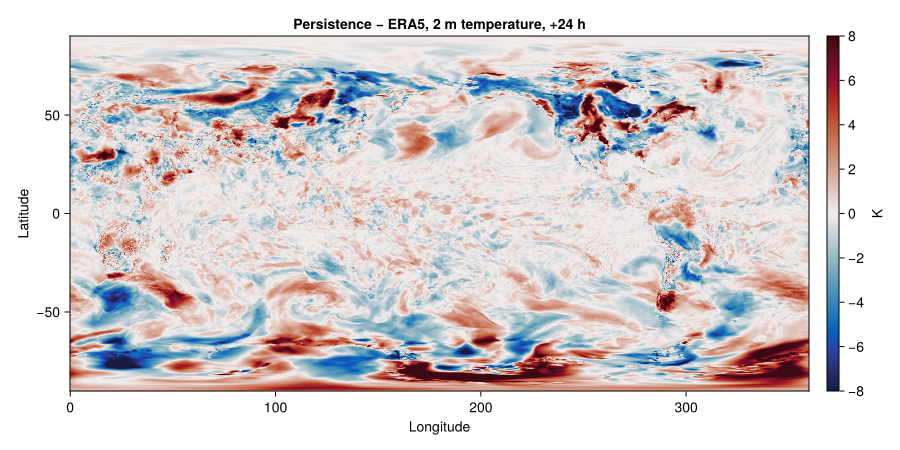

```julia
err24 = fc[end, :, :] - era[end, :, :]

fig = Figure(size=(900, 450))
ax = Axis(fig[1, 1]; title="Persistence − ERA5, 2 m temperature, +24 h", xlabel="Longitude", ylabel="Latitude")
hm = heatmap!(ax, lon, lat, permutedims(err24); colormap=:balance, colorrange=(-8, 8))
Colorbar(fig[1, 2], hm; label="K")
fig
```

## Trained models

Trained models ship as a *package*: weights plus configuration, downloaded from NGC or Hugging Face on first use. Each needs its model extra in `CondaPkg.toml` and, in practice, a GPU. For FourCastNet:

```
[pip.deps.earth2studio]
extras = ["fcn"]
```

The rest of the pipeline is unchanged. The model’s `input_coords()` reports the variables and grid it expects, and `run.deterministic` fetches exactly those from the data source.

```julia
pkg   = Earth2Studio.models.px.FCN.load_default_package()
model = Earth2Studio.models.px.FCN.load_model(pkg)
model.input_coords()["variable"]

io = Earth2Studio.io.ZarrBackend("forecast.zarr")
Earth2Studio.run.deterministic([t0], 20, model, ds, io)   # 20 × 6 h = 5 days
```

`run.deterministic` runs on CUDA when available and on CPU otherwise; pass `device` to override. The available models are listed in the upstream [model documentation](https://nvidia.github.io/earth2studio/main/modules/models.html). For ensemble forecasts, see `Earth2Studio.run.ensemble` in the Basics tutorial.